# Predicting Housing Prices

Shujing Yi & Yuehui Gong

2022-10-10

# Introduction

As Zillow has realized that its housing market predictions are not as accurate as they could be because they do not factor in enough local intelligence in Mecklenburg, this project is to improve Zillow’s housing market predictions for Mecklenburg.

To build a better housing price prediction regression model, our model includes three types of variables: external amenities, internal characteristics of houses from the given housing price dataset, and services from open data source, and spatial factors.

## Setup

```r
# You can set some global options for knitting chunks

knitr::opts_chunk$set(echo = TRUE)

# Load some libraries
library(tidyverse)
library(raster)
library(tidycensus)
library(sf)
library(spdep)
library(caret)
library(ckanr)
library(FNN)
library(grid)
library(gridExtra)
library(ggcorrplot) # plot correlation plot
library(corrr)      # another way to plot correlation plot
library(kableExtra)
library(jtools)     # for regression model plots
library(ggstance) # to support jtools plots
library(ggpubr)    # plotting R^2 value on ggplot point scatter
library(broom.mixed) # needed for effects plots
library(stargazer)

# functions and data directory
root.dir = "https://raw.githubusercontent.com/urbanSpatial/Public-Policy-Analytics-Landing/master/DATA/"

source("https://raw.githubusercontent.com/urbanSpatial/Public-Policy-Analytics-Landing/master/functions.r")

palette5 <- c("#25CB10", "#5AB60C", "#8FA108",   "#C48C04", "#FA7800")
```

# Data Wrangling and Feature Engineering

The given housing price dataset includes the housing price and internal characteristics information for each housing point. It is input as the base dataset for further feather engineering.

```r
sale <-
  st_read("data/studentData.geojson") %>%
  st_transform('ESRI:102286')
```

```r
Mecklenberg <-
  st_read("data/zipcode/zipcode.shp") %>%
  st_transform('ESRI:102286')
```

The following map visualize the distribution of housing points and their prices, which is represented in color.

It is clear the housing price distribution shows spatial clustering: the houses with high price, represented in orange, mainly distribute in the southern neighborhoods and other clusters near the county boundary.

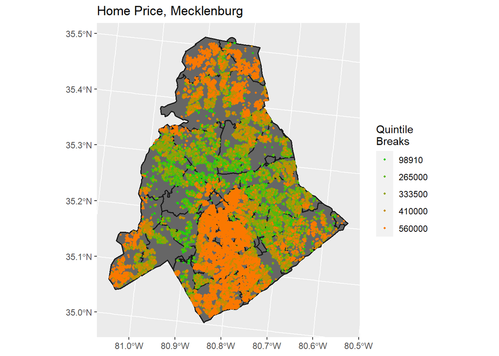

```r
ggplot() +
  geom_sf(data=Mecklenberg,fill = "grey40", color = "grey10",size= 0.7)+
  geom_sf(data = sale, aes(colour = q5(as.numeric(price))),
          show.legend = "point", size = .75) +
  scale_colour_manual(values = palette5,
                   labels=qBr(sale,"price"),
                   name="Quintile\nBreaks") +
  labs(title="Home Price, Mecklenburg")
```

## External Amenities

The first part of variables our model is to use the external amenities, the proximity to which could add value to houses. To get the data, we are using the open data portal for Mecklenburg. (http://maps.co.mecklenburg.nc.us/openmapping/data.html)

Our model is considering the following amenities and services: -Public Transportation: bus stop, station -Public Amenities: park, school -Potential negative factors: homeless shelter, flood, Landfill

### Bus Stop

As part of the public transportation system, being close to bus stops might add value to housing price. The following map shows the bus stops in Mecklenburg.

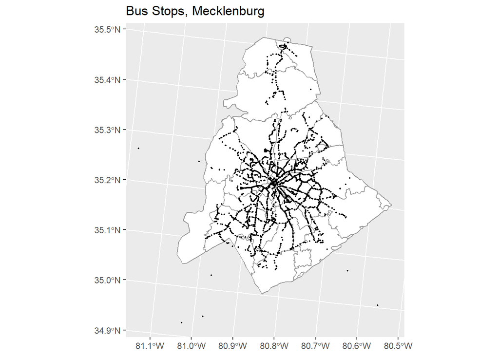

```r
busstop <- st_read("data/cats_busstops/CATS_BusStops.shp") #%>%
#st_transform(st_crs(tracts20))
ggplot() +
 geom_sf(data=Mecklenberg,fill = "white", color = "grey60",size= 0.5)+
  geom_sf(data = busstop,size= 0.3)+
    labs(title = "Bus Stops, Mecklenburg")
```

The distance from each house to the nearest bus stop is calculated as “bus_nn1”, which could be one important external variables for our model.

```r
sale <-
  sale %>%
    mutate(bus_nn1 = nn_function(st_coordinates(sale), st_coordinates(busstop), 1))
```

### Station

Similar to bus stops, metro station is a significant part of transportation service. The following map shows the station stops in Mecklenburg and “station_nn1” is measured as the nearest distance from house to metro station.

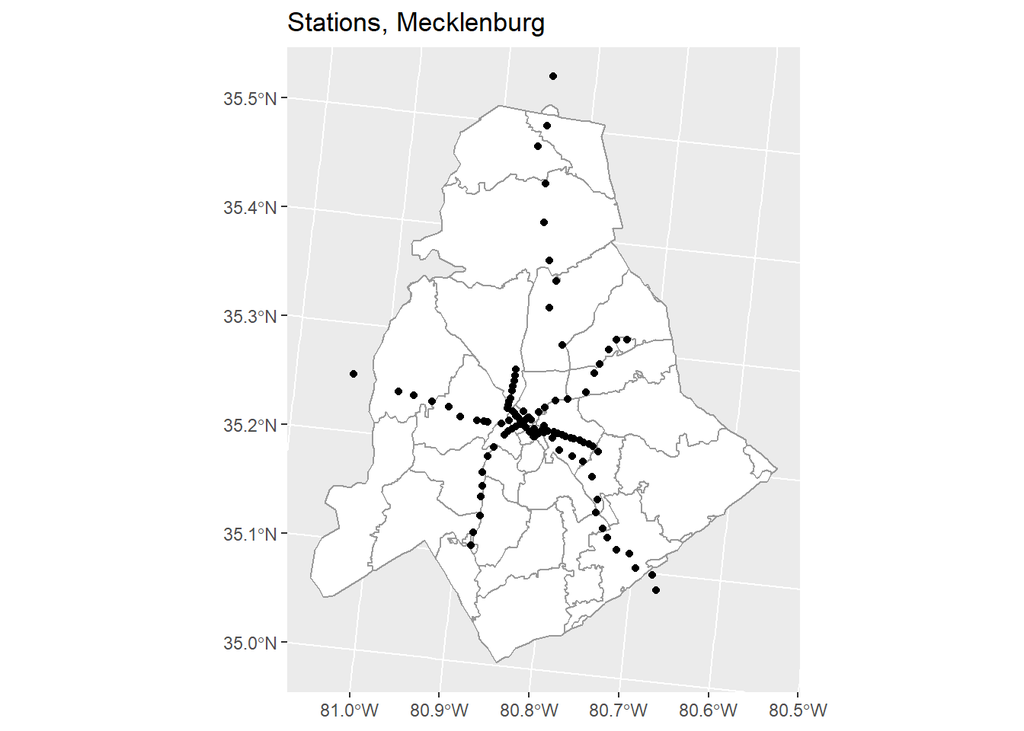

```r
station<- st_read("data/station_merge/station_merge.shp")
ggplot() +
 geom_sf(data=Mecklenberg,fill = "white", color = "grey60",size= 0.5)+
    geom_sf(data = station) +
    labs(title = "Stations, Mecklenburg")
```

```r
sale <-
  sale %>%
    mutate(station_nn1 = nn_function(st_coordinates(sale), st_coordinates(station), 1))
```

### Park

Park is serving as a public amenities for people’s daily recreation, as is shown in the following density map, and the distance to park could be considered. Thus, we are calculating the distance to the nearest park as “park_nn1” and mean distance to the 3 nearest parks as “park_nn3”. Further analysis would be down to select the more effective variable.

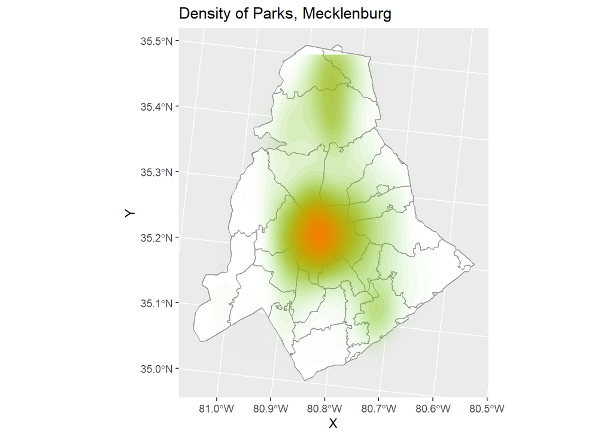

```r
park <- st_read("data/park_locations/Park_Locations.shp") %>%
              st_transform(st_crs(Mecklenberg))


ggplot() + geom_sf(data=Mecklenberg,fill = "white", color = "grey60",size= 0.5)+
  stat_density2d(data = data.frame(st_coordinates(park)),
                 aes(X, Y, fill = ..level.., alpha = ..level..),
                 size = 0.01, bins = 40, geom = 'polygon') +
  scale_fill_gradient(low = "#25CB10", high = "#FA7800",
                      breaks=c(0.000000003,0.00000003),
                      labels=c("Minimum","Maximum"), name = "Density") +
  scale_alpha(range = c(0.00, 0.35), guide = FALSE) +
  labs(title = "Density of Parks, Mecklenburg")
```

```r
sale <-
  sale %>%
    mutate(park_nn1 = nn_function(st_coordinates(sale), st_coordinates(park), 1),
           park_nn3 = nn_function(st_coordinates(sale), st_coordinates(park), 3))
```

### School

Also as an important amenity, we are using public school point data, including elementary, middle, high school and charter school. It might be more helpful to think of school district data, but it is not available from the open data source.

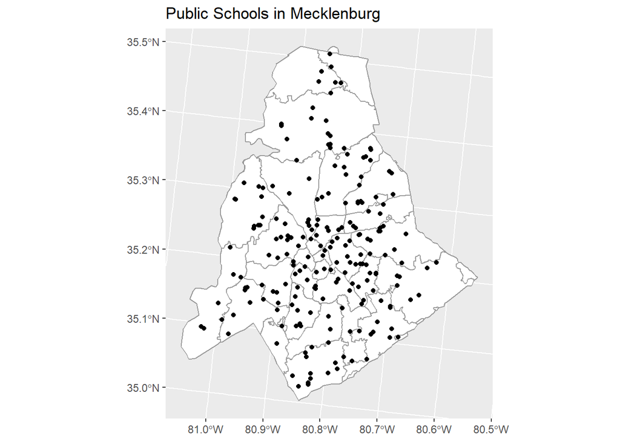

```r
school_public <- st_read("data/cms_schools/CMS_Schools.shp") %>%
              st_transform(st_crs(Mecklenberg)) %>%
  dplyr::select(city, address)

school_charter <- st_read("data/schools_charter/Schools_Charter.shp") %>%
              st_transform(st_crs(Mecklenberg)) %>%
    dplyr::select(city, address)


school<-rbind(school_public,school_charter)

ggplot()+
    geom_sf(data=Mecklenberg,fill = "white", color = "grey60",size= 0.5)+
  geom_sf(data=school)+
    labs(title = "Public Schools in Mecklenburg")
```

“school_nn1”, “school_nn2”, “school_nn3” are calculated as the mean distance to the nearest, 2 nearest and 3 nearest schools from each housing points.

```r
sale <-
  sale %>%
    mutate(school_nn1 = nn_function(st_coordinates(sale), st_coordinates(school), 1),
   school_nn2 = nn_function(st_coordinates(sale), st_coordinates(school), 2),
   school_nn3 = nn_function(st_coordinates(sale), st_coordinates(school), 3))
```

### Homeless Shelter

Homeless shelters is part of the potential negative factors, which are mainly located at the center of Mecklenberg county. Thus, the proximity to homeless shelter is calculated as “homelessshelter_nn1”.

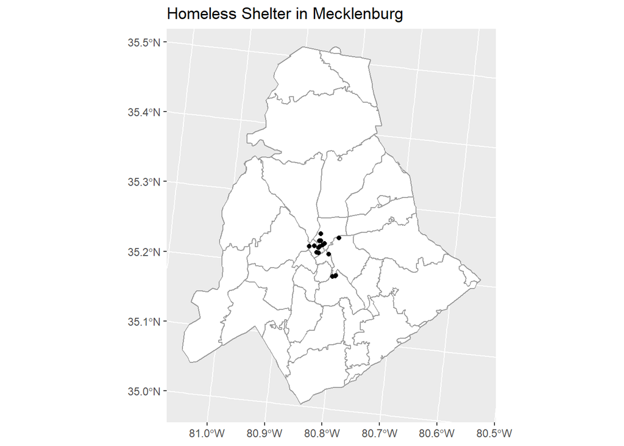

```r
homelessshelter <- st_read("data/homeless_shelters/Homeless_Shelters.shp") %>%
              st_transform(st_crs(Mecklenberg))
ggplot() +
  geom_sf(data=Mecklenberg,fill = "white", color = "grey60",size= 0.5)+
  geom_sf(data = homelessshelter, fill = "red")+
  labs(title = "Homeless Shelter in Mecklenburg")
```

```r
sale <-
  sale %>%
    mutate(homelessshelter_nn1 = nn_function(st_coordinates(sale), st_coordinates(homelessshelter), 1))
```

### Landfill

Another potential negative factor which might impact the housing price is the landfill. The landfill parcels are visualized in the map.

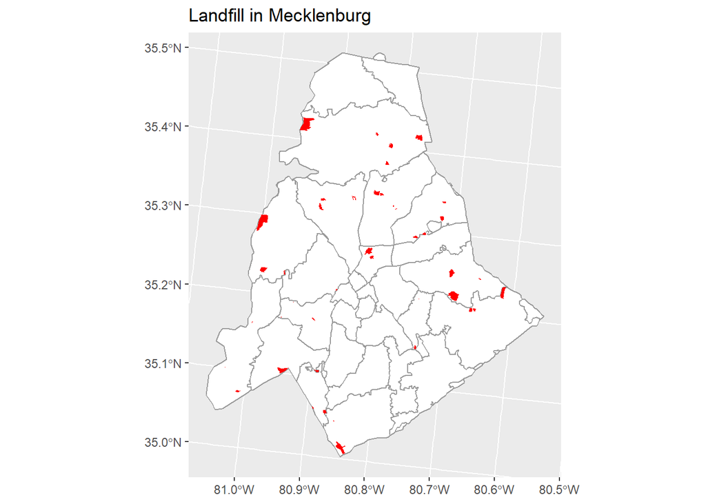

```r
landfill <- st_read("data/landfills/Landfills.shp") %>%
              st_transform(st_crs(Mecklenberg))


ggplot() +
  geom_sf(data=Mecklenberg,fill = "white", color = "grey60",size= 0.5)+
  geom_sf(data = landfill, fill = "red", color = "transparent") +
   labs(title = "Landfill in Mecklenburg")
```

To do the feature engineering, we use st_centroid to extract the center points and then calculate the nearest distance from houses to landfill center points.

```r
sale <-
  sale %>%
    mutate(landfill = nn_function(st_coordinates(sale), st_coordinates(st_centroid(landfill)), 1))
```

### Floodplain

We find flooding might be another concern when people are buying their houses, which means whether or not the houses are within the 100 year floodplain could a significant variable for our model. The map shows the 100 year floodplain along the water way.

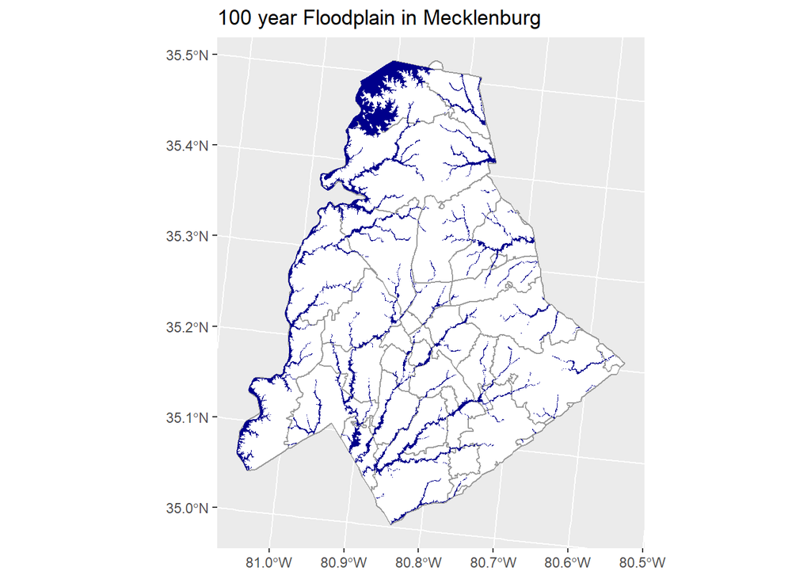

```r
flood100y <- st_read("data/femaexisting_100yr_floodplain/FEMAExisting_100yr_Floodplain.shp") %>%
              st_transform(st_crs(Mecklenberg))
ggplot() +
  geom_sf(data=Mecklenberg,fill = "white", color = "grey60",size= 0.5)+
  geom_sf(data = flood100y, fill = "dark blue",color="transparent") +
  labs(title = "100 year Floodplain in Mecklenburg")
```

Then we map the houses within the floodplain in red in the following map. We create a binary variable called “flood100y” to assign “1” to houses within the floodplain and “0” to houses that will not be impacted by 100 year flood.

```r
salegroup <-
  rbind(
    sale[flood100y,] %>%
      st_drop_geometry() %>%
      left_join(sale) %>%
      st_sf() %>%
      mutate(flood100y = 1),
   sale[flood100y, op = st_disjoint] %>%
      st_drop_geometry() %>%
      left_join(sale) %>%
      st_sf() %>%
      mutate(flood100y = 0))

salegroup <- salegroup[!duplicated(salegroup$musaID), ]
```

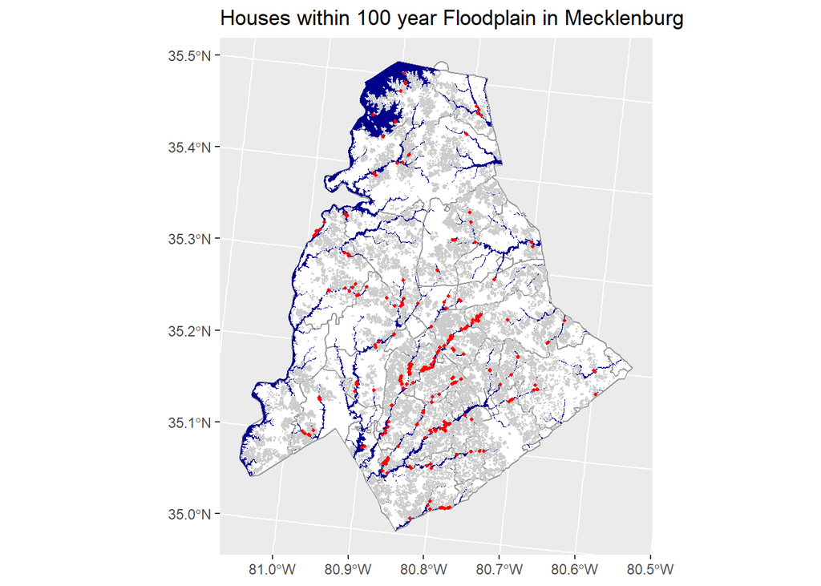

```r
floodpt<-
  salegroup %>%
  filter(flood100y == 1)

ggplot() +
  geom_sf(data=Mecklenberg,fill = "white", color = "grey60",size= 0.5)+
  geom_sf(data = flood100y, fill = "dark blue",color="transparent") +
     geom_sf(data = salegroup,  col = "grey80",
          show.legend = "point", size = .2) +
  geom_sf(data = floodpt, col = "red",
          show.legend = "point", size = .7) +
  labs(title = "Houses within 100 year Floodplain in Mecklenburg")
```

## Internal Characteristics

The second part of variables for our model is the internal characteristics, which are the variables of the housing characteristics from the given housing data.

The following is the variables to consider: -Heated area -Bedrooms -Full baths -Half baths -Housing age -Housing story height -Fire place number -Foundation types -Heated fuel types -Architecture types -Units -Account types

In this part, we are doing feature engineering to either transform numeric variables to categorical variables or recategorize the categorical variables to increase the model accuracy.

### Categorical Bar Plot

To identify the categorical variables which have high correlation with price, we first make the bar plots showing price as a function of categorical variables.

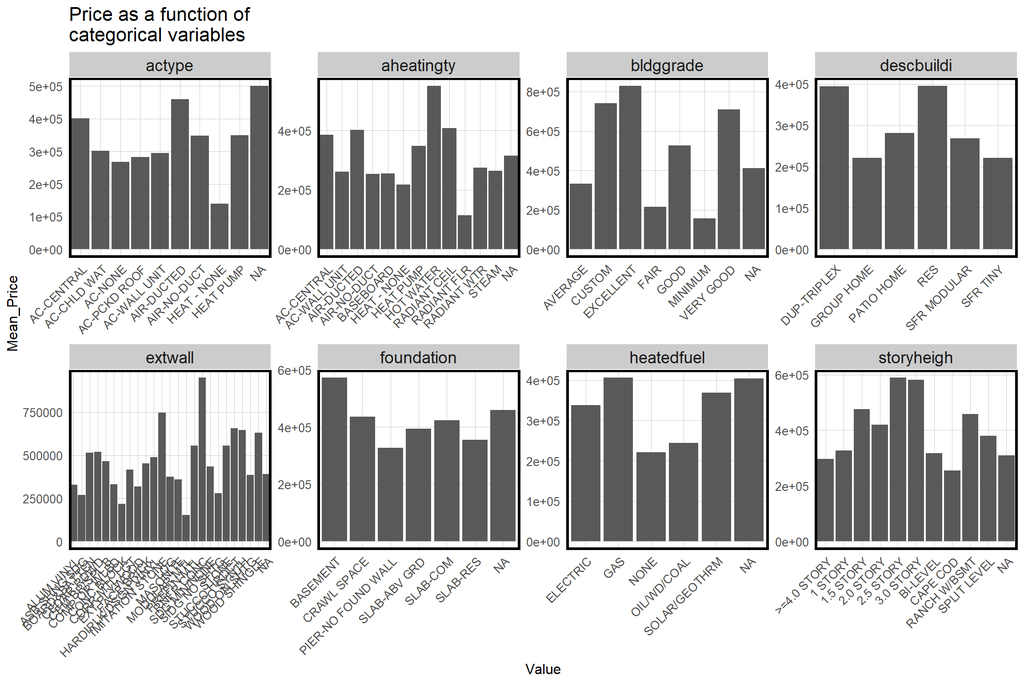

```r
st_drop_geometry(salegroup) %>%
  dplyr::select(price, descbuildi, storyheigh, aheatingty, heatedfuel,actype,extwall,foundation, bldggrade,
                ) %>%
  filter(price <= 1000000) %>%
  gather(Variable, Value, -price) %>%
   ggplot(aes(Value, price)) +
     geom_bar(position = "dodge", stat = "summary", fun.y = "mean") +
     facet_wrap(~Variable, ncol = 4, scales = "free") +
     labs(title = "Price as a function of\ncategorical variables", y = "Mean_Price") +
     plotTheme() + theme(axis.text.x = element_text(angle = 45, hjust = 1))
```

It shows that the variables of architecture type, building grade, heated fuel type and story height are all correlated with sale price and they can be our potential variables.

### Age

One key characteristics of a house to consider is its age. We first calculate the age (age = 2022 - yearbuilt).

```r
salegroup <-
  salegroup %>%
  mutate(age = 2022 - yearbuilt)
```

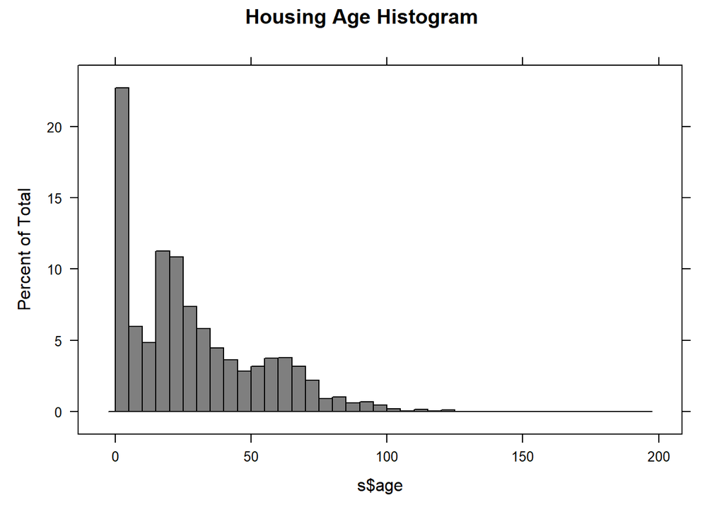

```r
s <-salegroup %>%
  filter(age <= 200)
histogram(s$age,main="Housing Age Histogram",breaks=40,col = c("grey50"))
```

The age now is a numeric variable, which doesn’t correlate strongly with the price. To transform them into categorical variables, we want to identify the different ranges to categorize the age variable, so we make this histogram. Based on the age histogram, we decide to categorize the age into four ranges in “age.cat” variable:

age >= 0 & age <15 ~ “Up to 15yrs”, age >= 15 & age < 50 ~ “15-50yrs”, age >= 50 & age < 75 ~ “50-75yrs”,  
age >= 75 ~ “75+yrs”

```r
salegroup <-
  salegroup %>%
  mutate(age.cat = case_when(
                  age >= 0 & age <15  ~ "Up to 15yrs",
                  age >= 15 & age < 50  ~ "15-50yrs",
                  age >= 50 & age < 75  ~ "50-75yrs",
                  age >= 75  ~ "75+yrs"),)
```

### Story Height

We think it might be helpful to recategorize the story height class. So we use “recode” to get the “story.cat” variable of 5 class:

“1.0 STORY”= “1story”,“1 STORY”= “1story” “1.5 STORY” = “2story”, “2.0 STORY” = “2story”,“BI-LEVEL”=“2story”,“SPLIT LEVEL”=“2story” “2.5 STORY”=“3story”,“3.0 STORY”=“3story” “CAPE COD”=“other”,“RANCH W/BSMT”=“other” “>=4story”

```r
glimpse(s$storyheigh)


salegroup$story.cat <- recode(salegroup$storyheigh,"1.0 STORY"= "1story","1 STORY"= "1story", "1.5 STORY" = "2story", "2.0 STORY" = "2story","BI-LEVEL"="2story","SPLIT LEVEL"="2story","2.5 STORY"="3story","3.0 STORY"="3story","CAPE COD"="other","RANCH W/BSMT"="other")
```

## Spatial Factors

### Census Tract

To take spatial clustering into consideration, we then use census tract data and neighborhood effect as the spatial factors to help the model better understand the spatial clustering.

By importing the census tract data, we collect the total population, white population, female bachelors, male bachelors, median income, median rent, total poverty.

We then calculate the variables of white population percentage, bachelor percentage, poverty percentage to make it easier to do the comparison among census tracts.

```r
census_api_key("a78f5d0c0fd577cd3f16136b5a87d6ecdb62ffba", overwrite = TRUE)

tracts <-
  get_acs(geography = "tract",
          variables = c("B25026_001E","B02001_002E",
                        "B15001_050E","B15001_009E",
                        "B19013_001E", "B25058_001E",
                        "B06012_002E"),
          year=2020, state="NC",
          county="Mecklenburg County", geometry=TRUE) %>%
  st_transform('ESRI:102286')
```

```r
tracts <-
  tracts %>%
  dplyr::select( -NAME, -moe) %>%
  spread(variable, estimate) %>%
  rename(TotalPop = B25026_001,
         Whites = B02001_002,
         FemaleBachelors = B15001_050,
         MaleBachelors = B15001_009,
         MedHHInc = B19013_001,
         MedRent = B25058_001,
         TotalPoverty = B06012_002)

tracts <-
  tracts %>%
  mutate(pctWhite = ifelse(TotalPop > 0, Whites / TotalPop, 0),
         pctBachelors = ifelse(TotalPop > 0, ((FemaleBachelors + MaleBachelors) / TotalPop), 0),
         pctPoverty = ifelse(TotalPop > 0, TotalPoverty / TotalPop, 0)) %>%
  dplyr::select(-Whites,-FemaleBachelors,-MaleBachelors,-TotalPoverty)
```

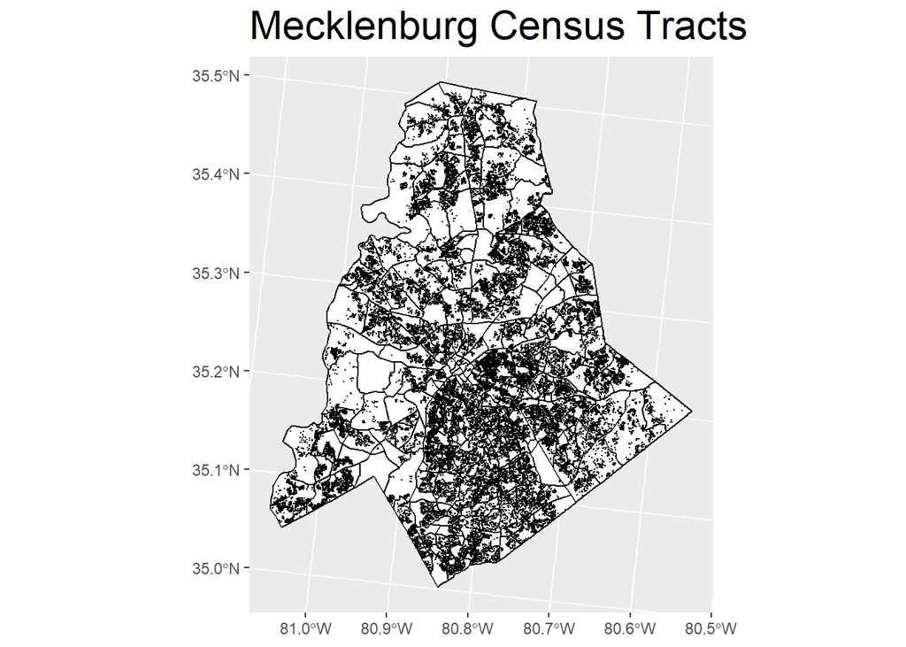

```r
ggplot()+
  geom_sf(data = tracts, fill = "white", color = "black")+
  geom_sf(data=salegroup,
          show.legend = "point", size= 0.1) +
  labs(title = "Mecklenburg Census Tracts") +
  theme(plot.title = element_text(size=22))
```

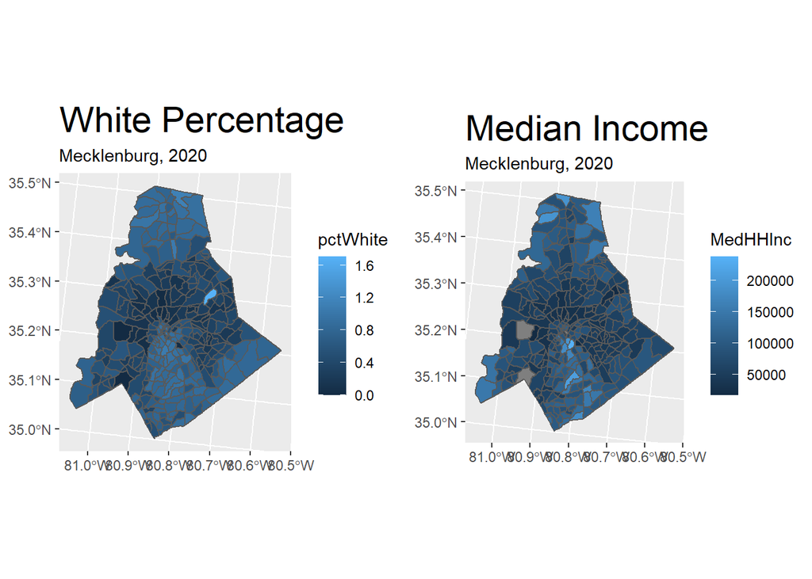

```r
A2<-
  ggplot() +
  geom_sf(data = tracts, aes(fill = pctWhite)) +
  labs(title = "White Percentage", subtitle = "Mecklenburg, 2020") +
  theme(plot.title = element_text(size=22))
A3<-
  ggplot() +
  geom_sf(data = tracts, aes(fill = MedHHInc)) +
  labs(title = "Median Income", subtitle = "Mecklenburg, 2020") +
  theme(plot.title = element_text(size=22))
grid.arrange(A2,A3, nrow = 1)
```

So following is the spatial variables for our model:

-White percentage -Bachelor percentage -Poverty percentage -Median income -Median rent

```r
salegroup<-st_intersection(salegroup,tracts)
```

```r
salegroup<-st_intersection(salegroup,Mecklenberg)
```

## Table of summary statistics

```r
stargazer(as.data.frame(salegroup[c("price","heatedarea","bedrooms","fullbaths","halfbaths","numfirepla","foundation","heatedfuel","actype","units","accounttyp","shape_Area")]), type="text",
          title="Internal Characteristics", digits=1)
```

```
##
## Internal Characteristics
## =========================================================
## Statistic    N      Mean    St. Dev.    Min       Max
## ---------------------------------------------------------
## price      46,178 465,706.6 602,441.5    0    75,500,000
## heatedarea 46,178  2,359.5   1,060.4    0.0    14,710.0
## bedrooms   46,178    3.5       0.9       0        65
## fullbaths  46,178    2.3       0.8       0         9
## halfbaths  46,178    0.6       0.5       0         4
## numfirepla 46,178    0.8       0.5       0         7
## units      46,178    1.0       1.0       0        205
## shape_Area 46,178 15,873.9  35,035.0  1,139.6 3,486,865.0
## ---------------------------------------------------------
```

```r
stargazer(as.data.frame(salegroup[c("park_nn1","homelessshelter_nn1","landfill","flood100y","school_nn1","bus_nn1","station_nn1")]), type="text",
          title="Amenities/public Services", digits=1)
```

```
##
## Amenities/public Services
## =======================================================================
## Statistic             N       Mean     St. Dev.     Min         Max
## -----------------------------------------------------------------------
## park_nn1            46,178   1,248.8    773.3      21.1       5,063.9
## homelessshelter_nn1 46,178  11,806.7   6,565.5     91.1      29,089.3
## landfill            46,178   3,077.6   1,576.8      8.6       9,764.0
## flood100y           46,178    0.01       0.1         0           1
## school_nn1          46,178   1,379.0    921.8      35.9       6,898.7
## bus_nn1             46,178 2,042,743.0 9,451.4  2,020,346.0 2,068,794.0
## station_nn1         46,178 2,083,970.0 9,432.1  2,061,509.0 2,109,944.0
## -----------------------------------------------------------------------
```

```r
stargazer(as.data.frame(salegroup[c("TotalPop","pctWhite","pctBachelors","pctPoverty", "MedHHInc")]), type="text",
          title="Spatial Structure", digits=1)
```

```
##
## Spatial Structure
## ====================================================
## Statistic      N      Mean   St. Dev.  Min     Max
## ----------------------------------------------------
## TotalPop     46,178 4,030.5  1,310.3   790    7,703
## pctWhite     46,178   0.6      0.3     0.01    1.7
## pctBachelors 46,178   0.01     0.01    0.0     0.3
## pctPoverty   46,178   0.1      0.1     0.0     0.6
## MedHHInc     46,178 86,172.3 37,414.1 17,685 238,750
## ----------------------------------------------------
```

```r
salegroup_challenge <- salegroup %>%
  filter (salegroup$toPredict == "CHALLENGE")
salegroup <- salegroup %>%
  filter (salegroup$toPredict == "MODELLING")
```

## Home Price Correlation Scatter Plots

To understand how some of the continuous variables correlate with housing price, we get the correlation scatter plots.

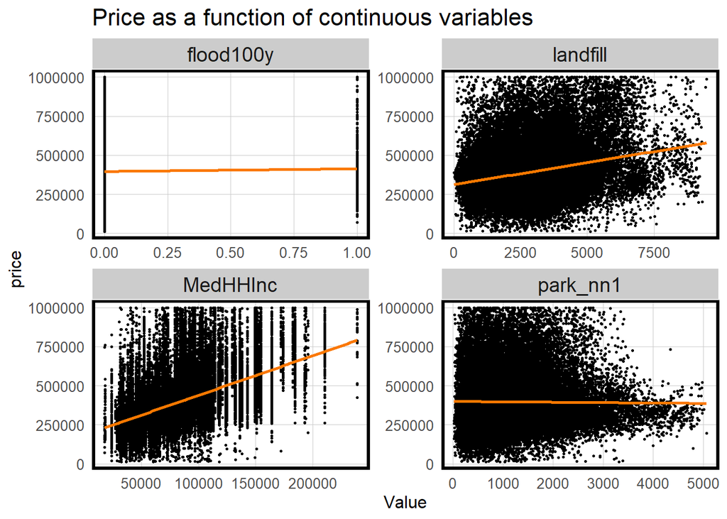

```r
st_drop_geometry(salegroup) %>%
  dplyr::select(price,park_nn1,landfill,flood100y,MedHHInc) %>%
  filter(price <= 1000000) %>%
  gather(Variable, Value, -price) %>%

   ggplot(aes(Value, price)) +
     geom_point(size = .5) + geom_smooth(method = "lm", se=F, colour = "#FA7800") +
     facet_wrap(~Variable, ncol = 2, scales = "free") +
     labs(title = "Price as a function of continuous variables") +
     plotTheme()
```

For the 100 year flood and landfill, it makes sense that the further distance to landfills the higher housing price will be and but it is strange to see that the houses in floodplain have slightly higher price.

## Correlation Matrix

Correlation matrix is produced to see the relationship between the continuous variables.Three separate correlation matrix are made for each part of our variables. To further simplify the correlation plot, only one variable is kept for each amenity.

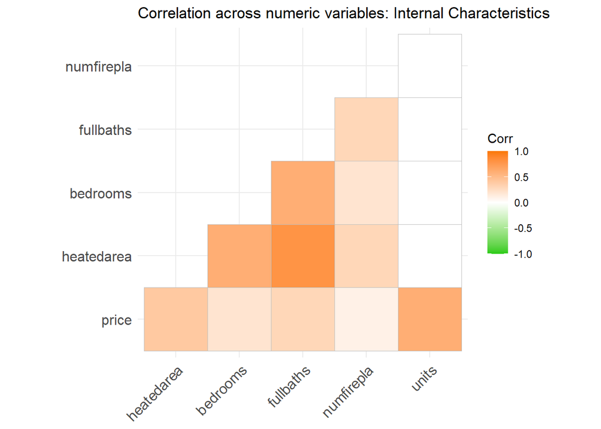

```r
numericVars <-
  select_if(st_drop_geometry(salegroup), is.numeric) %>% na.omit()%>%
  dplyr::select(price,heatedarea,bedrooms,fullbaths,numfirepla,units)

ggcorrplot(
  round(cor(numericVars), 1),
  p.mat = cor_pmat(numericVars),
  colors = c("#25CB10", "white", "#FA7800"),
  type="lower",
  insig = "blank") +
    labs(title = "Correlation across numeric variables: Internal Characteristics")
```

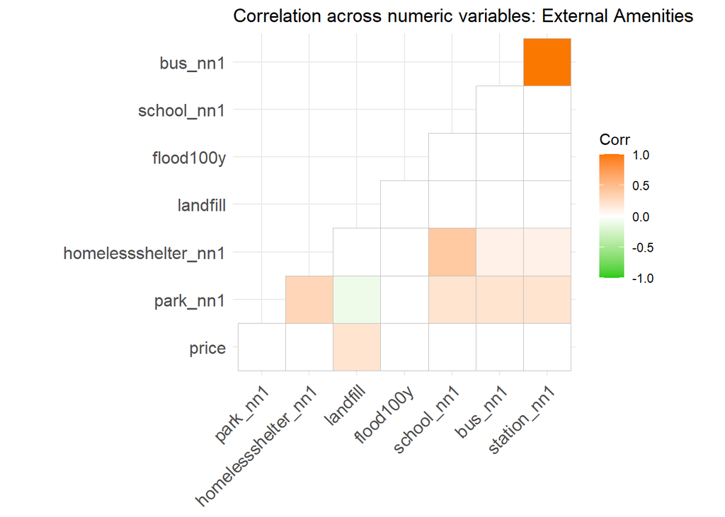

```r
numericVars <-
  select_if(st_drop_geometry(salegroup), is.numeric) %>% na.omit()%>%
  dplyr::select(price,park_nn1,homelessshelter_nn1,landfill,flood100y,school_nn1,bus_nn1,station_nn1)

ggcorrplot(
  round(cor(numericVars), 1),
  p.mat = cor_pmat(numericVars),
  colors = c("#25CB10", "white", "#FA7800"),
  type="lower",
  insig = "blank") +
    labs(title = "Correlation across numeric variables: External Amenities")
```

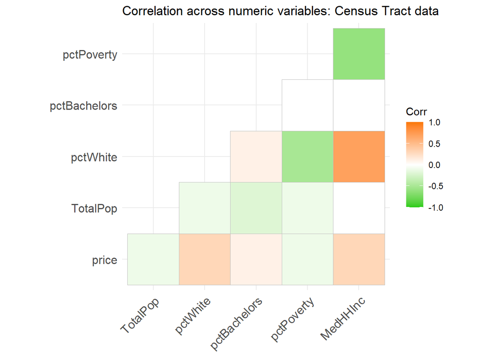

```r
numericVars <-
  select_if(st_drop_geometry(salegroup), is.numeric) %>% na.omit()%>%
  dplyr::select(price,TotalPop,pctWhite,pctBachelors,pctPoverty, MedHHInc)

ggcorrplot(
  round(cor(numericVars), 1),
  p.mat = cor_pmat(numericVars),
  colors = c("#25CB10", "white", "#FA7800"),
  type="lower",
  insig = "blank") +
    labs(title = "Correlation across numeric variables: Census Tract data")
```

# Methods

After data wrangling and feature engineering, we build our regression model. Linear Regression, or Ordinary Least Squares Regression (OLS), is used to predict the price of a house as a function of several components.

In the result of a regression model, the p-value is a direct way to measure if the coefficient is reliable and is a standard measure of statistical significance. (Adjusted) R^2 is a standard regression ‘goodness of fit’ indicator that describes how well the features explain the outcome.

For this project, we attempted to maximize our model’s generalizability. We randomly split our data into training and stretching sets to test our models’ generalizability. Then we performed regressions, adding one dependent variable at a time and determining whether the model’s mean absolute error (MAE) and R^2 went up or down.

# Results

## Split dataframe into training and testing datasets

Below, after selecting all the “MODELLING” data from our dataset,salegroup was split into a 60% Mecklenberg.training dataset and a 40% Mecklenberg.test dataset, with control to include all levels of categorical variables (storyheigh, age.cat, heatedfuel, actype, etc.).

```r
set.seed(5)
inTrain <- createDataPartition(
              y = paste(salegroup$storyheigh,salegroup$age.cat,salegroup$heatedfuel, salegroup$actype,salegroup$foundation,salegroup$accounttyp),
              p = .60, list = FALSE)
Mecklenberg.training <- salegroup[inTrain,]
Mecklenberg.test <- salegroup[-inTrain,]
```

## training set regression

The output below is a summary of our model. The summary of r-squared and adjusted r-squared for the training sample is also demonstrated below. Generally, about 68% of the variance of the dependent variable is explained in this prediction.

```r
reg.training <- lm(price ~ ., data = st_drop_geometry(Mecklenberg.training) %>%
                                 dplyr::select(price, heatedarea, bedrooms,
                                               age.cat,storyheigh,fullbaths, halfbaths,
                                               numfirepla,foundation,heatedfuel,units,accounttyp, park_nn1,homelessshelter_nn1,landfill,flood100y,school_nn1,bus_nn1,station_nn1,bldggrade,
                                               TotalPop,pctWhite,pctBachelors,pctPoverty,MedHHInc,zip,shape_Area))

stargazer(reg.training, type="text", digits=3)
```

```
##
## ========================================================
##                                  Dependent variable:
##                              ---------------------------
##                                         price
## --------------------------------------------------------
## heatedarea                           131.403***
##                                        (4.773)
##
## bedrooms                             -5,880.064*
##                                      (3,093.219)
##
## age.cat50-75yrs                      -11,418.480
##                                      (9,161.850)
##
## age.cat75+yrs                       36,124.010***
##                                     (13,922.070)
##
## age.catUp to 15yrs                  45,517.440***
##                                      (6,543.583)
##
## storyheigh1 STORY                    104,109.600
##                                     (217,348.800)
##
## storyheigh1.5 STORY                  86,950.150
##                                     (217,422.300)
##
## storyheigh2.0 STORY                  57,458.000
##                                     (217,284.100)
##
## storyheigh2.5 STORY                  25,616.370
##                                     (217,666.400)
##
## storyheigh3.0 STORY                  26,250.160
##                                     (224,139.200)
##
## storyheighBI-LEVEL                   36,749.820
##                                     (220,201.600)
##
## storyheighCAPE COD                   100,518.800
```

[output cut: 211 more lines]

```
##
## shape_Area                            2.379***
##                                        (0.058)
##
## Constant                         -39,292,906.000***
##                                    (6,704,043.000)
##
## --------------------------------------------------------
## Observations                           27,865
## R2                                      0.685
## Adjusted R2                             0.684
## Residual Std. Error           374,508.600 (df = 27781)
## F Statistic                  729.236*** (df = 83; 27781)
## ========================================================
## Note:                        *p<0.1; **p<0.05; ***p<0.01
```

## Test Set

In this test set, the mean absolute error is 112144, while the Mean Absolute Percent Error is about 28%.

```r
Mecklenberg.test <-
  Mecklenberg.test %>%
  mutate(Regression = "Baseline Regression",
         SalePrice.Predict = predict(reg.training, Mecklenberg.test),
         SalePrice.Error = SalePrice.Predict - price,
         SalePrice.AbsError = abs(SalePrice.Predict - price),
         SalePrice.APE = (abs(SalePrice.Predict - price)) / SalePrice.Predict)%>%
  filter(price < 5000000)
```

```r
data.frame(Mean_Absolute_Error = mean(Mecklenberg.test$SalePrice.AbsError, na.rm = T),
           Mean_Absolute_Percent_Error =mean(Mecklenberg.test$SalePrice.APE, na.rm = T))%>%
  kable() %>%
  kable_styling()
```

| Mean_Absolute_Error | Mean_Absolute_Percent_Error |
| --- | --- |
| 112144.7 | 0.2851468 |

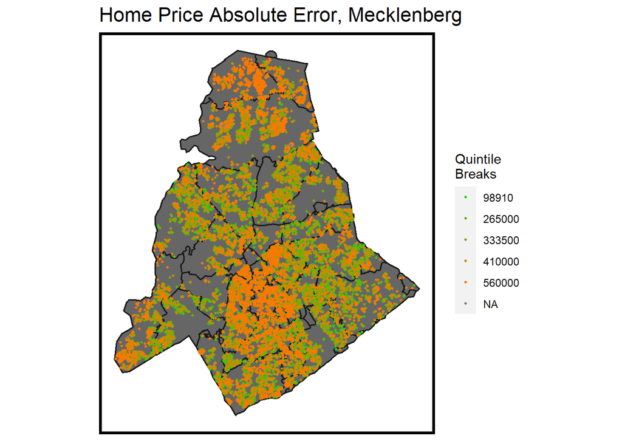

```r
ggplot() +
  geom_sf(data=Mecklenberg,fill = "grey40", color = "grey10",size= 0.7)+
  geom_sf(data = Mecklenberg.test, aes(colour = q5(as.numeric(SalePrice.AbsError))),
          show.legend = "point", size = .75) +
  scale_colour_manual(values = palette5,
                   labels=qBr(sale,"price"),
                   name="Quintile\nBreaks") +
  labs(title="Home Price Absolute Error, Mecklenberg") +
  mapTheme()
```

## Cross validation

```r
fitControl <- trainControl(method = "cv", number = 100)
set.seed(825)

reg.cv <-
  train(price ~ ., data = st_drop_geometry(salegroup) %>%
                                dplyr::select(price, heatedarea, bedrooms,
                                               age.cat,storyheigh,fullbaths,halfbaths,
                                               numfirepla,foundation,heatedfuel,units,accounttyp, park_nn1,homelessshelter_nn1,landfill,flood100y,school_nn1,bus_nn1,station_nn1,bldggrade,
                                               TotalPop,pctWhite,pctBachelors,pctPoverty,MedHHInc,zip,shape_Area),
     method = "lm", trControl = fitControl, na.action = na.pass)

reg.cv
```

```
## Linear Regression
##
## 46078 samples
##    26 predictor
##
## No pre-processing
## Resampling: Cross-Validated (100 fold)
## Summary of sample sizes: 45617, 45617, 45617, 45616, 45618, 45618, ...
## Resampling results:
##
##   RMSE      Rsquared  MAE
##   288880.1  0.665514  118335.4
##
## Tuning parameter 'intercept' was held constant at a value of TRUE
```

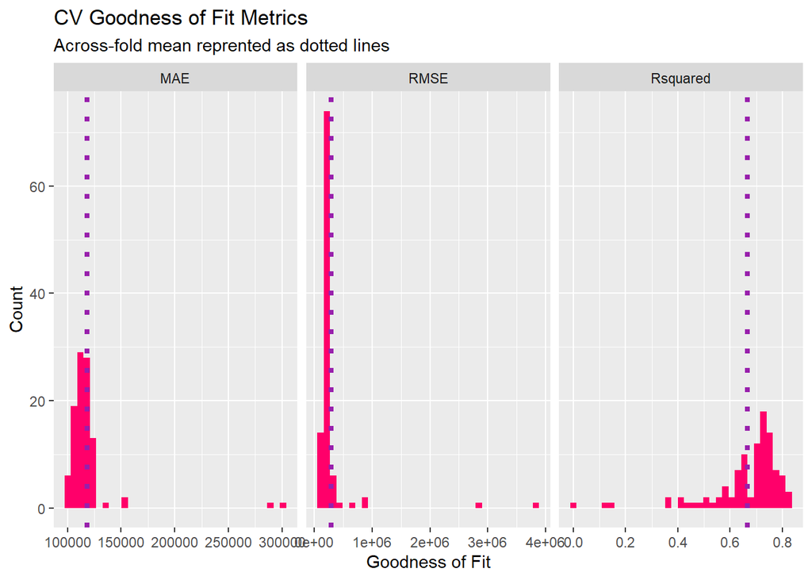

```r
dplyr::select(reg.cv$resample, -Resample) %>%
  gather(metric, value) %>%
  left_join(gather(reg.cv$results[2:4], metric, mean)) %>%
  ggplot(aes(value)) +
    geom_histogram(bins=35, fill = "#FF006A") +
    facet_wrap(~metric,scales = "free_x") +
    geom_vline(aes(xintercept = mean), colour = "#981FAC", linetype = 3, size = 1.5) +

    labs(x="Goodness of Fit", y="Count", title="CV Goodness of Fit Metrics",
         subtitle = "Across-fold mean reprented as dotted lines")
```

## Map of Predicted Values

```r
CHALLENGE <-
  salegroup_challenge %>%
  mutate(Regression = "Neighborhood Effects",
         SalePrice.Predict = predict(reg.training, salegroup_challenge),
        )%>%
  rename(prediction = SalePrice.Predict)


MODELLING <-
  salegroup %>%
  mutate(Regression = "Neighborhood Effects",
         SalePrice.Predict = predict(reg.training, salegroup),
        )%>%
  rename(prediction = SalePrice.Predict)

TOTAL <- rbind(CHALLENGE, MODELLING )
```

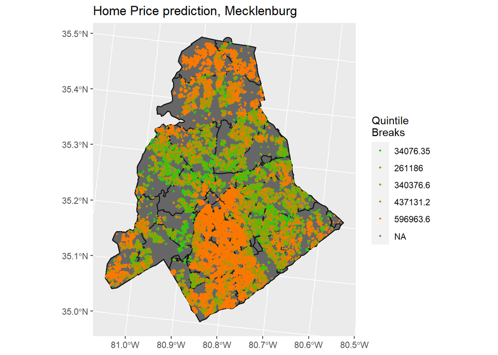

```r
ggplot() +
  geom_sf(data=Mecklenberg,fill = "grey40", color = "grey10",size= 0.7)+
  geom_sf(data = TOTAL, aes(colour = q5(as.numeric(prediction))),
          show.legend = "point", size = .75) +
  scale_colour_manual(values = palette5,
                   labels=qBr(TOTAL,"prediction"),
                   name="Quintile\nBreaks") +
  labs(title="Home Price prediction, Mecklenburg")
```

## Predicted Prices as a Function of Observed Prices

As we analyze the test set which occupied 40% of the total set, the prediction model still has some inaccuracy. The graphic below shows the sale price compared with the price prediction.

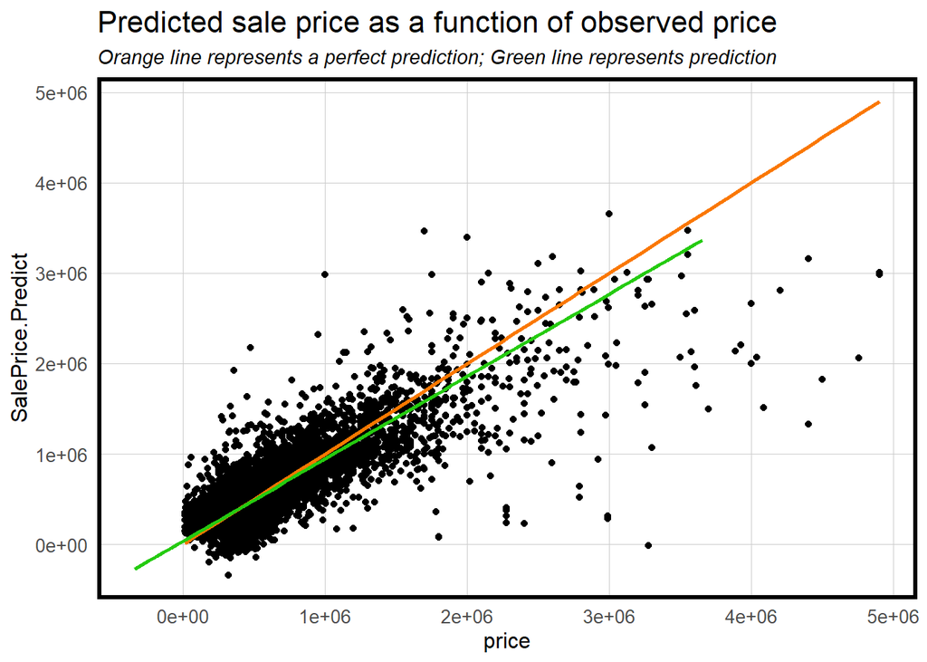

```r
Mecklenberg.test %>%
  dplyr::select(SalePrice.Predict, price) %>%
    ggplot(aes(price, SalePrice.Predict)) +
  geom_point() +
  stat_smooth(aes(price, price),
             method = "lm", se = FALSE, size = 1, colour="#FA7800") +
  stat_smooth(aes(SalePrice.Predict, price),
              method = "lm", se = FALSE, size = 1, colour="#25CB10") +
  labs(title="Predicted sale price as a function of observed price",
       subtitle="Orange line represents a perfect prediction; Green line represents prediction") +
  plotTheme()
```

## Spatial Correlation of error

```r
coords.test <- st_coordinates(Mecklenberg.test)

neighborList.test <- knn2nb(knearneigh(coords.test, 5))

spatialWeights.test <- nb2listw(neighborList.test, style="W")

Mecklenberg.test$lagPrice <- lag.listw(spatialWeights.test, Mecklenberg.test$price)
Mecklenberg.test$lagPriceError<-lag.listw(spatialWeights.test, Mecklenberg.test$SalePrice.Error, NAOK = TRUE)

#Mecklenberg.test %>%
  #mutate(lagPriceError = lag.listw(spatialWeights.test, SalePrice.Error, NAOK = TRUE)) %>%
  #ggplot(aes(lagPriceError, SalePrice.Error))
```

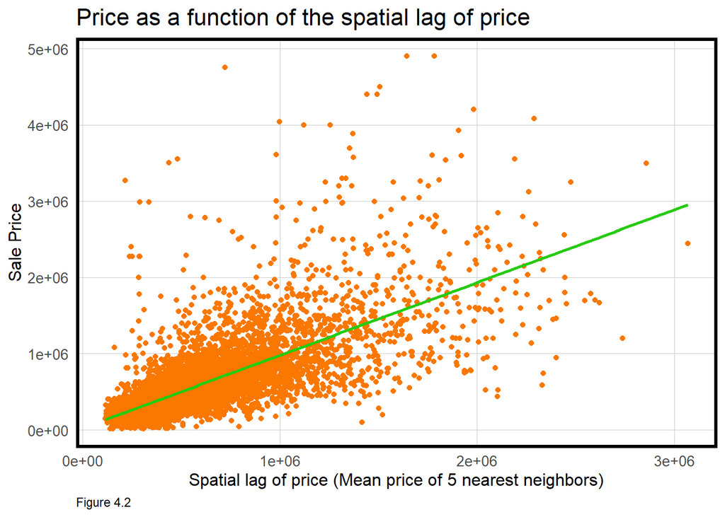

```r
ggplot(Mecklenberg.test, aes(x=lagPrice, y=price)) +
  geom_point(colour = "#FA7800") +
  geom_smooth(method = "lm", se = FALSE, colour = "#25CB10") +
  labs(title = "Price as a function of the spatial lag of price",
       caption = "Figure 4.2",
       x = "Spatial lag of price (Mean price of 5 nearest neighbors)",
       y = "Sale Price") +
  plotTheme()
```

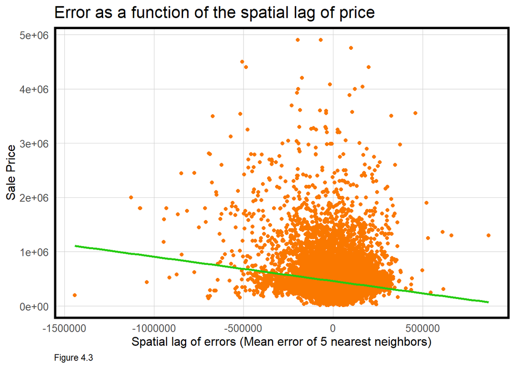

```r
ggplot(Mecklenberg.test, aes(x=lagPriceError, y=price)) +
  geom_point(colour = "#FA7800") +
  geom_smooth(method = "lm", se = FALSE, colour = "#25CB10") +
  labs(title = "Error as a function of the spatial lag of price",
       caption="Figure 4.3",
       x = "Spatial lag of errors (Mean error of 5 nearest neighbors)",
       y = "Sale Price") +
  plotTheme()
```

## Moran’s

The frequency of all 999 randomly permutated I are plotted as a histogram with the Observed I indicated by the orange line. That the observed I is higher than all of the 999 randomly generated I’s provides visual confirmation of spatial autocorrelation.

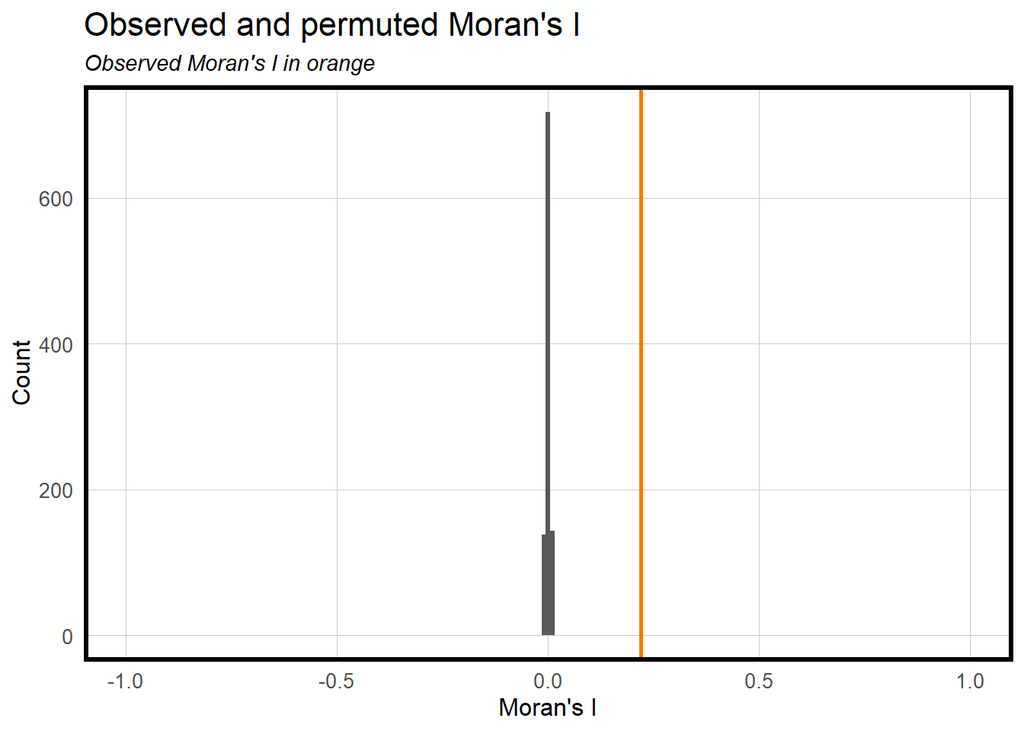

```r
moranTest <- moran.mc(Mecklenberg.test$SalePrice.Error,
                      spatialWeights.test, nsim = 999, na.action=na.omit)

ggplot(as.data.frame(moranTest$res[c(1:999)]), aes(moranTest$res[c(1:999)])) +
  geom_histogram(binwidth = 0.01) +
  geom_vline(aes(xintercept = moranTest$statistic), colour = "#FA7800",size=1) +
  scale_x_continuous(limits = c(-1, 1)) +
  labs(title="Observed and permuted Moran's I",
       subtitle= "Observed Moran's I in orange",
       x="Moran's I",
       y="Count") +
  plotTheme()
```

## Accounting for neighborhood

```r
# Errors by neighborhood
left_join(
  st_drop_geometry(Mecklenberg.test) %>%
    group_by(zip) %>%
    summarize(meanPrice = mean(price, na.rm = T)),
  mutate(Mecklenberg.test, predict.fe =
                        predict(lm(price ~ zip, data = Mecklenberg.test),
                        Mecklenberg.test)) %>%
    st_drop_geometry %>%
    group_by(zip) %>%
      summarize(meanPrediction = mean(predict.fe))) %>%
      kable() %>% kable_styling()
```

| zip | meanPrice | meanPrediction |
| --- | --- | --- |
| 28027 | 414875.0 | 414875.0 |
| 28031 | 705237.9 | 705237.9 |
| 28036 | 594261.4 | 594261.4 |
| 28078 | 448926.7 | 448926.7 |
| 28104 | 465531.2 | 465531.2 |
| 28105 | 422973.6 | 422973.6 |
| 28107 | 454833.3 | 454833.3 |
| 28134 | 367000.0 | 367000.0 |
| 28202 | 780571.4 | 780571.4 |
| 28203 | 916384.4 | 916384.4 |
| 28204 | 773694.9 | 773694.9 |
| 28205 | 503064.1 | 503064.1 |
| 28206 | 288755.0 | 288755.0 |
| 28207 | 1598731.4 | 1598731.4 |
| 28208 | 283812.6 | 283812.6 |
| 28209 | 803774.8 | 803774.8 |
| 28210 | 567730.8 | 567730.8 |
| 28211 | 965960.5 | 965960.5 |
| 28212 | 286681.6 | 286681.6 |
| 28213 | 291027.8 | 291027.8 |
| 28214 | 307676.0 | 307676.0 |
| 28215 | 309864.0 | 309864.0 |
| 28216 | 303132.1 | 303132.1 |
| 28217 | 261395.6 | 261395.6 |
| 28226 | 663411.7 | 663411.7 |
| 28227 | 354516.9 | 354516.9 |
| 28262 | 335820.5 | 335820.5 |
| 28269 | 312176.6 | 312176.6 |
| 28270 | 595425.2 | 595425.2 |
| 28273 | 326538.1 | 326538.1 |
| 28277 | 593920.0 | 593920.0 |
| 28278 | 477558.3 | 477558.3 |

## Accuracy of the neighborhood mode

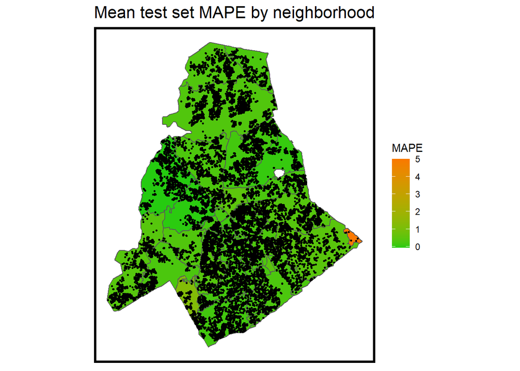

```r
st_drop_geometry(Mecklenberg.test) %>%
  group_by(zip) %>%
  summarize(mean.MAPE = mean(SalePrice.APE, na.rm = T)) %>%
  ungroup() %>%
  left_join(Mecklenberg) %>%
    st_sf() %>%
    ggplot() +
      geom_sf(aes(fill = mean.MAPE)) +
      geom_sf(data = Mecklenberg.test, colour = "black", size = .5) +
      scale_fill_gradient(low = palette5[1], high = palette5[5],
                          name = "MAPE") +
      labs(title = "Mean test set MAPE by neighborhood") +
      mapTheme()
```

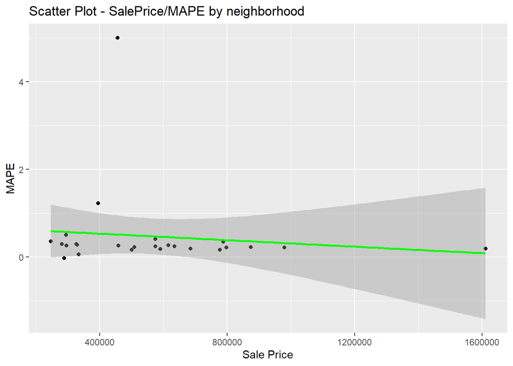

```r
Mecklenberg_sum <- Mecklenberg.test %>%
  group_by(zip) %>%
  summarise(meanMAPE = mean(SalePrice.APE),
            meanPrice = mean(SalePrice.Predict))


ggplot(Mecklenberg_sum, aes(x = meanPrice, y = meanMAPE)) +
  geom_point() +
  geom_smooth(method = "lm", color = "green") +
  labs(title = "Scatter Plot - SalePrice/MAPE by neighborhood",
       x = "Sale Price",
       y = "MAPE") +
  theme(
    legend.position = "none"
  )
```

## Generalizability by Income

Finally, we calculated MAPE for below/above average home income to test the model’s generalizability. The results indicate that our model has a slightly higher MAPE in high-income census tracts than in low-income ones, but very close. The model is generalizable.

```r
mean(tracts$MedHHInc, na.rm = T)
```

```
## [1] 77915.22
```

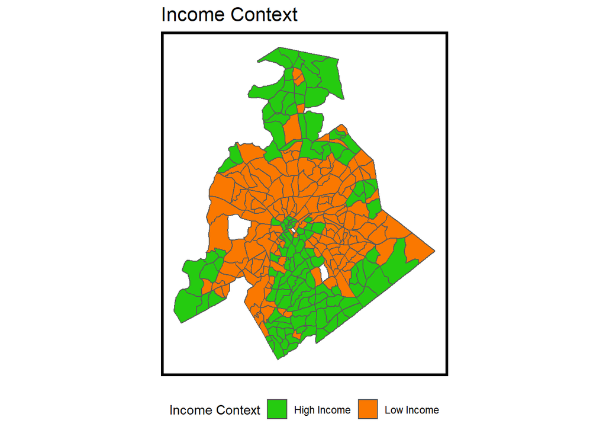

```r
tracts <-
  tracts%>%
  mutate(incomeContext = ifelse(MedHHInc > 77915, "High Income", "Low Income"))

ggplot() + geom_sf(data = na.omit(tracts), aes(fill = incomeContext)) +
    scale_fill_manual(values = c("#25CB10", "#FA7800"), name="Income Context") +
    labs(title = "Income Context") +
    mapTheme() + theme(legend.position="bottom")
```

```r
st_join(Mecklenberg.test, tracts) %>%
  filter(!is.na(incomeContext)) %>%
  group_by(incomeContext) %>%
  summarize(mean.MAPE = scales::percent(mean(SalePrice.APE, na.rm = T))) %>%
  st_drop_geometry() %>%
  spread(incomeContext, mean.MAPE) %>%
  kable(caption = "Test set MAPE by neighborhood income context")
```

Test set MAPE by neighborhood income context

| High Income | Low Income |
| --- | --- |
| 29% | 27% |

# Discussion

We build our sketch model by thinking about the variables of internal characteristics, external amenities, and spatial factors and doing feature engineering. Considering the neighborhood effect could significantly increase the model accuracy and decrease our sale price APE.

However, our model is still not accurate enough to help Zillow to predict the housing price, since our MAE is around $112,144, which means a big gap between the predicted and real price.

The barriers for us probably include not identifying some key internal characteristics variables and not having access to some external data like crime data and school district data, which we believe would improve our price prediction model a lot.

# Conclusion

Although some features in our model show strong correlation with the housing price, there is still a room to improve our model considering the MAE, MAPE and r-squared. We could consider inviting more data to improve the model. Also, non-linear models other OLS can be considered for better fit.